# Network models

Forrest W. Crawford

# Overview

## Why Networks?

One of the most important features of modern agent-based modeling approaches is the idea of heterogeneity of interactions.

Social, sexual, epidemiological, and communication networks exhibit rich local and global structure that influences the propagation of diseases, behaviors, practices, and beliefs through human societies.

Representing relationships between individuals has proven to be a challenge to quantitative and applied scientists.

In this section, we hope to provide a brief introduction to networks as they are formulated and used in models for public health applications.

## Motivation

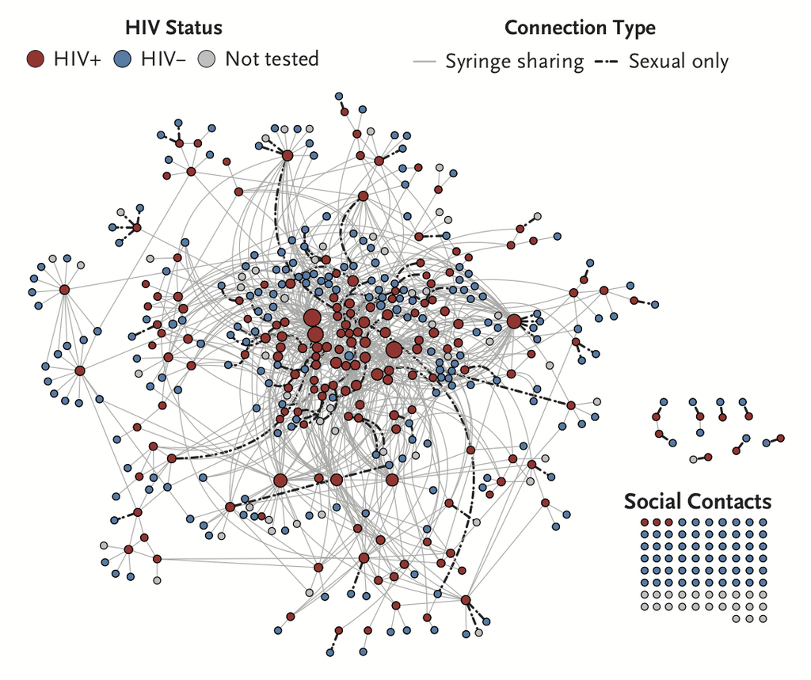

## Motivation

Sometimes, instead of data about isolated units (humans, usually) and their attributes/outcomes, we have relational data about the connections between units.

Networks are *data structures* for representing relational information.

Some people think networks are transcendental data structures that can reveal many hidden truths about the human condition.

I don’t, but I do think networks are very useful.

But there are a lot of pitfalls in analyzing network data. Many data analysis heuristics and existing statistical tools do not work for network data, and may give misleading results.

# Network basics

## Network notation

Mathematicians call networks *graphs*. A graph consists of: - a set $V$ of *vertices* (nodes, subjects, units, egos) - a set $E$ of *edges* (links, arcs, connections, relationships)
$$E = \{ \{i,j\} \text{ for } i,j\in V\}$$

$$V = \{1,2,3,4,5,6,7,8\}$$
$$E = \{ \{1,2\},
\{2,3\},
\{2,4\},
\{2,7\},
\{3,7\},
\{4,5\},
\{5,7\},
\{5,6\},
\{6,8\},
\{7,8\} \}$$

## Examples of networks $G=(V,E)$

| Network | Vertices ($V$) | Edges ($E$) |
| --- | --- | --- |
| Social | people | friendships |
| Publication | articles | citations |
| Publication | authors | co-authorships |
| Phylogenetic | species | ancestral relationships |
| Trade | countries | trade relationships |
| Gene expression | genes | interactions |
| Brain | cortical regions | fiber tracts |
| Neural | neurons | axons |
| Injection | people | needle sharing partners |

## Types of networks: directed/undirected

An undirected network has symmetric links. A *directed* network has directed links

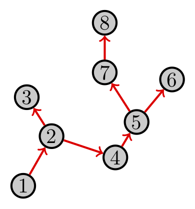

Edges in a directed graph are usually denoted as *ordered* pairs, e.g. $E=\{ (i,j):\ i \to j\}$.

## Types of networks: weighted

In a *weighted* network, each edge $\{i,j\}\in E$ has a numeric attribute $z_{ij}$.

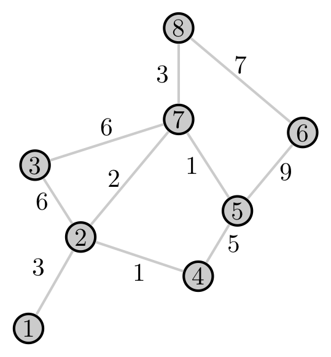

Sometimes we define $z_{ij}=0$ if $\{i,j\}\notin E$.

## Special types of graphs

Graphs can be

- empty ($E=\emptyset$)
- complete ($E=\{ \{i,j\} \text{ for all } i,j\in V\}$)
- connected (all vertices are connected to each other via a path)
- acyclic (tree, DAG)
- planar (no crossing edges)
- sparse (not too many edges)
- dense (lots of edges)

There are lots of other types of graphs!

## Terminology: degree

The *degree* of a vertex is the number of edges incident to it:
$$d_i = |\{j\in V:\ \{i,j\}\in E\}|$$

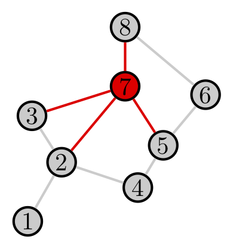

Vertex 7 has degree $d_7=4$. Sometimes social scientists call this the *egocentric network size* or just *network size*.

For directed graphs, we distinguish between

- *in-degree* $d^\text{in}_i=|\{j:\ (j,i)\in E\}|$
- *out-degree* $d^\text{out}_i =|\{j:\ (i,j)\in E\}|$

## Representing networks

Consider a graph $G=(V,E)$.

*Adjacency matrix*: $A_{ij} = 1$ if and only if $\{i,j\}\in E$.

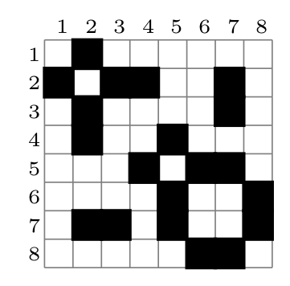

- $A_{ij}=A_{ji}$ for an undirected graph, so $A$ is symmetric.
- $A_{ii} = 0$ for all $i\in V$ if no self-loops.
- The elements of the adjacency matrix might be $A_{ij}=z_{ij}$ in a weighted graph.

## Viewing networks: principles

Visualizing a network requires a *layout algorithm* that tells your computer where to put each of the vertices relative to each other in two dimensions.

Layout algorithms try to place vertices in 2 dimensions so that:

- vertices do not overlap
- few edges overlap
- network components are evident
- community structure is evident
- path length corresponds to spatial distance But, it is *very* difficult to achieve all these goals simultaneously.

I recommend:

- Use visualization to gain insight, not to make arguments.
- Start with a circular-by-degree layout.

## One network, many hairballs

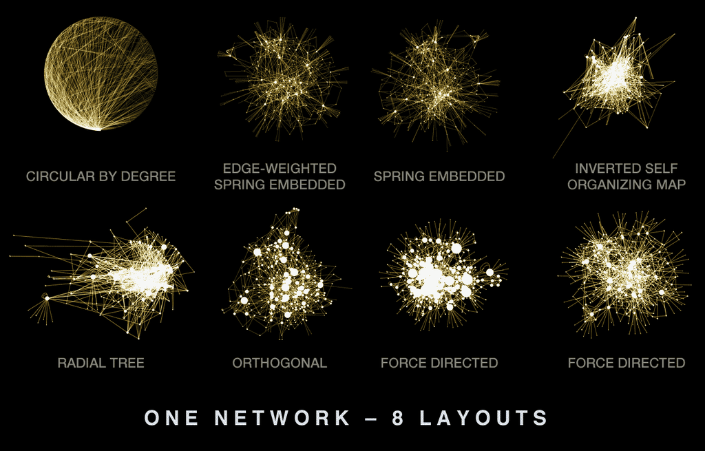

www.hiveplot.com

## Viewing networks: algorithms and pitfalls

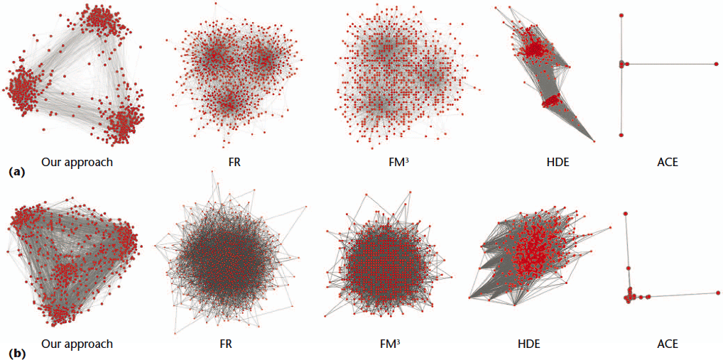

Hu, Lu, Wu, “Spectrum-Based Network Visualization for Topology Analysis”, *IEEE Computer Graphics and Applications* 33, pages 58-68, 2013.

# Network models

## Why models?

Why do we need models for networks? Networks are complicated, and there are lots of them. By constructing models, learn about the structure of a complicated object using a small number of parameters.

## How many networks?

One reason we need models is that there are *a lot* of networks:

- Number of undirected graphs on $n$ vertices: $2^{\binom{n}{2}}$
- Number of directed graphs on $n$ vertices: $2^{n(n-1)}$

*Example* For a graph $G=(V,E)$ with $n = |V| = 50$, there are approximately $5.77\times 10^{368}$ possible undirected graphs and $3.34\times 10^{737}$ directed graphs. There are about $10^{80}$ atoms in the known universe.

This means that it can be prohibitively difficult to enumerate them for even modest $n$.

So it is helpful to have a model with fewer parameters than $2^{\binom{n}{2}}$ that helps us summarize networks.

## Network models

A *network model* is a set of networks $\mathcal{G}$ and a probability function $\Pr(\cdot)\ge 0$ that maps networks to probabilities.

*Probabilistic network models and parameter estimation*: If you have a probability model $\Pr(\cdot|\theta)$, where $\theta$ is a set of parameters, and you observe a network $G$, you might want to find the value of $\theta$ that maximizes the probability of the network. In other words,
$$\hat\theta = \arg\max_{\theta} \Pr(G|\theta)$$
This is called “maximum likelihood”.

There are many other ways to estimate parameters.

## Network model: Erdos-Renyi

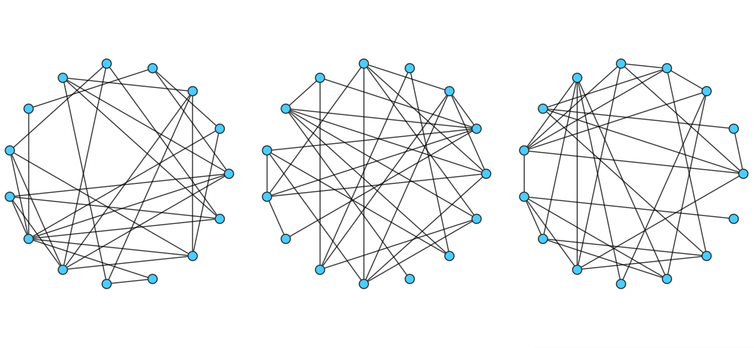

Is the ER model a good model for human social networks? Does the Erdos-Renyi model produce *community structure*?

## Exponential random graph models (ERGMs)

Good things: - easy to parameterize in low dimension - can capture complex global topological properties

Bad things: - intractable normalizing constant $\kappa(\theta)$ - difficulty fitting - degeneracy

## ERGMs

Examples of ERGM sufficient statistics

- $h(G) = |E|$ (Erdos-Renyi)
- $h(G) = ( |E|, \text{triangles}$ ) (dyads and triangles)
- $h(G) = (AKS_\lambda, \text{triangles})$ (alternating $k$-star statistic) with
  $$AKS_\lambda(G) = \sum_{k=1}^{n-1} (-1)^k \frac{S_k(G)}{\lambda^{k-2}}$$
  where $S_k(G)$ is the number of $k$-stars in $G$. It is *not* true that every function $h(G)$ yields a valid joint distribution over graphs $\mathcal{G}$.

## Exchangeable: SBM

Exchangeable graphs have the property that their distribution is invariant to permutation of the vertex labels.

The stochastic block model (SBM) is a graph in which each vertex $i\in V$ has a categorical attribute $x_i\in\{1,\ldots,K\}$. The attribute $x_i$ is called the “block” membership of $i$.

Define a $K\times K$ matrix
$$P = \begin{pmatrix}
p_{11} & p_{12} & \cdots & p_{1K} \\
p_{21} & p_{22} & \cdots & p_{2K} \\
\vdots & \vdots & \ddots & \vdots \\
p_{K1} & p_{K2} & \cdots & p_{KK} \\
\end{pmatrix}$$
that defines the edge probabilities between each of the $K$ “blocks”.

An edge between $i$ and $j$ is formed with probability $P_{x_i,x_j}$.

## Exchangeable: SBM

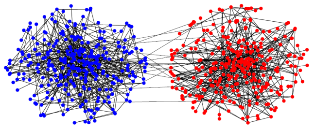

See also: degree-corrected SBM.

## Other network models

There are lots of other network models designed to capture important features of real-world networks.

One of the main features is a “heavy-tailed” degree distribution in which most vertices have small degree, and some have very large degree.

Further reading:

- Scale-free, power-law, Barab'asi-Albert, preferential attachment
- Small world, Watts-Strogatz
- Exchangeable (graphon)
- Degree-corrected SBM

Kolaczyk and Csárdi (2014), Kolaczyk (2009), Newman (2010), Jackson (2010)

## Network processes

Dynamic or stochastic processes on networks are beyond the scope of this talk. However, you might be interested in further reading on:

- Random walks on networks, and their equilibrium distributions
- Markov random fields as coherent models for vertex outcomes
- Clifford-Hammersley theorem, Brooks’ Lemma for existence of valid joint distributions on vertex outcomes
- Diffusions, cascades
- Epidemics on networks
- (Economic) Games on networks, equilibria

## References

Jackson, Matthew O. 2010. *Social and Economic Networks*. Princeton University Press.

Kolaczyk, Eric D. 2009. *Statistical Analysis of Network Data: Methods and Models*. Springer Science & Business Media.

Kolaczyk, Eric D, and Gábor Csárdi. 2014. *Statistical Analysis of Network Data with R*. Vol. 65. Springer.

Newman, Mark. 2010. *Networks: An Introduction*. Oxford University Press.